# examenbioinformatica_2022

Borja Gracia Loroño

31/1/2022

## EJERCICIO 1: COMANDOS DE LINUX :

1. Palabras en el fichero:

   cat genes.txt | wc -w
2. Cambio de tabulados por guiones

   cat genes.txt | sed ‘s/-/g’
3. Como cambiarias solo la primera aparición

   cat genes.txt | sed ‘s/-’
4. Buscar todos los genes menos el DSTYK

   cat genes.txt | -v grep DSTYK

## EJERCICIO 2: PREGUNTAS BÁSICAS

```r
library(nycflights13)
library(tidyverse)
library(lubridate)
```

1. Cuantas columnas y cuantos registros tiene el dataset

```r
tiempo <- nycflights13::weather

dim(tiempo)
```

```
## [1] 26115    15
```

```r
print("Aparecen en el dataset 26.115 registros y 15 columnas")
```

```
## [1] "Aparecen en el dataset 26.115 registros y 15 columnas"
```

2. ¿Cuantos origin aparecen y para cada uno de ellos cuantos registros hay?

```r
table(tiempo$origin)
```

```
##
##  EWR  JFK  LGA
## 8703 8706 8706
```

```r
print("Observamos que aparecen 3 origin diferentes y cada uno de ellos con los registros indicados en la pantalla")
```

```
## [1] "Observamos que aparecen 3 origin diferentes y cada uno de ellos con los registros indicados en la pantalla"
```

3. En LGA, ¿cuales fueron la mediana del wind_speed y la media de pressure?

```r
data_LGA <- tiempo[tiempo$origin == "LGA",]

median(data_LGA$wind_speed)
```

```
## [1] 10.35702
```

```r
mean(data_LGA$pressure, na.rm = T,)
```

```
## [1] 1017.678
```

```r
print("Aquí observamos la mediana del wind_speed y la media de pressure")
```

```
## [1] "Aquí observamos la mediana del wind_speed y la media de pressure"
```

d.Después de eliminar los NA de la columna wind_gust, calcula para cada mes la media de wind_speed y wind_gust, y el número de casos.

```r
tiempo_sin_na <- tiempo[complete.cases(tiempo$wind_gust),]

dif_meses <- tiempo_sin_na %>%
  group_by(month) %>%
  summarise(media_wind_speed = mean(wind_speed),
            media_wind_gust = mean(wind_gust),
            n_casos = n()
  )
  dif_meses
```

```
## # A tibble: 12 x 4
##    month media_wind_speed media_wind_gust n_casos
##    <int>            <dbl>           <dbl>   <int>
##  1     1             18.4            27.5     535
##  2     2             19.4            28.2     612
##  3     3             17.7            26.2     795
##  4     4             17.1            25.6     582
##  5     5             16.6            25.0     352
##  6     6             15.4            23.4     436
##  7     7             13.6            21.4     253
##  8     8             14.2            21.9     221
##  9     9             14.5            22.3     265
## 10    10             15.9            23.8     338
## 11    11             18.5            27.6     622
## 12    12             16.1            24.4     326
```

## EJERCICIO 3: PLOTS

1. Crea el siguiente plot:

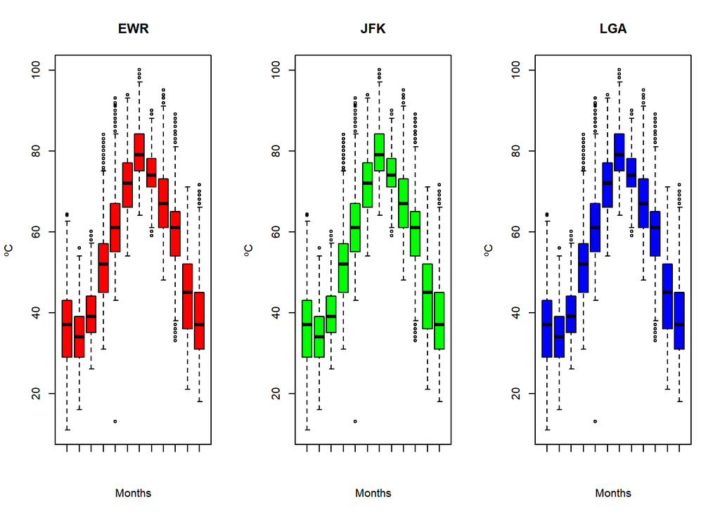

```r
data_EWR <- tiempo[tiempo$origin == "EWR",]
data_JFK <- tiempo[tiempo$origin == "JFK",]

par(mfrow = c(1,3))
mes1 <- weather[weather$month == 1, ]
mes2 <- weather[weather$month == 2, ]
mes3 <- weather[weather$month == 3, ]
mes4 <- weather[weather$month == 4, ]
mes5 <- weather[weather$month == 5, ]
mes6 <- weather[weather$month == 6, ]
mes7 <- weather[weather$month == 7, ]
mes8 <- weather[weather$month == 8, ]
mes9 <- weather[weather$month == 9, ]
mes10 <- weather[weather$month == 10, ]
mes11 <- weather[weather$month == 11, ]
mes12 <- weather[weather$month == 12, ]

boxplot(mes1$temp, mes2$temp, mes3$temp, mes4$temp, mes5$temp, mes6$temp, mes7$temp, mes8$temp, mes9$temp, mes10$temp, mes11$temp, mes12$temp, xlab = "Months", ylab = "ºC", main = "EWR", col = "red")

boxplot(mes1$temp, mes2$temp, mes3$temp, mes4$temp, mes5$temp, mes6$temp, mes7$temp, mes8$temp, mes9$temp, mes10$temp, mes11$temp, mes12$temp, xlab = "Months", ylab = "ºC", main = "JFK", col = "green")

boxplot(mes1$temp, mes2$temp, mes3$temp, mes4$temp, mes5$temp, mes6$temp, mes7$temp, mes8$temp, mes9$temp, mes10$temp, mes11$temp, mes12$temp, xlab = "Months", ylab = "ºC", main = "LGA", col = "blue")
```

b.Crea la función:

```r
plot_function <- function(temp, titulo, unidades)
{
boxplot(mes1$temp, mes2$temp, mes3$temp, mes4$temp, mes5$temp, mes6$temp, mes7$temp, mes8$temp, mes9$temp, mes10$temp, mes11$temp, mes12$temp, xlab = "Months", ylab = "ºC", main = "EWR", col = "red")

boxplot(mes1$temp, mes2$temp, mes3$temp, mes4$temp, mes5$temp, mes6$temp, mes7$temp, mes8$temp, mes9$temp, mes10$temp, mes11$temp, mes12$temp, xlab = "Months", ylab = "ºC", main = "JFK", col = "green")

boxplot(mes1$temp, mes2$temp, mes3$temp, mes4$temp, mes5$temp, mes6$temp, mes7$temp, mes8$temp, mes9$temp, mes10$temp, mes11$temp, mes12$temp, xlab = "Months", ylab = "ºC", main = "LGA", col = "blue")

}
{
  print(mean(data_EWR$temp, na.rm = T))
  print(mean(data_JFK$temp, na.rm = T))
  print(mean(data_LGA$temp, na.rm = T))
}
```

```
## [1] 55.54655
## [1] 54.47215
## [1] 55.76261
```